# Problem Set 3

Statistics and Econometrics

Deadline: 10am, 16 Nov 2023

## General Guideline

What we are looking for in the assignments is a demonstration that you can understand the econometrics and statistics questions and can solve them with R or conceptually. That means effective programming to get correct results is needed, but at the same time, clear explanations of economics/business concepts in well presented reports are equally important when assessing your work. In particular, you will be marked for successful (correct) programming (not the style of coding), good understanding of related concepts, and clear interpretations and explanations of results.

Please submit a pdf or html file converted from R markdown/notebook after you program in R.

## Question 1 (40 marks)

Use the data in kielmc.RData (only those observations from 1981) to answer the following questions. The data are for houses that sold during 1981 in North Andover, Massachusetts; 1981 was the year construction began on a local garbage incinerator. We want to study the effects of the incinerator location on housing price. Two key variables are: $price$ is housing price in dollars and $dist$ is distance from the house to the incinerator measured in feet.

1. There are two alternative specifications of the simple regression model: (1) regress $price$ on $dist$; (2) regress $\log(price)$ on $\log(dist)$. Plot the two OLS lines on the corresponding scatter plots, and discuss which one would you use for the study.

**answer 1.1**

```r
# load and filter the data
load("kielmc.RData")
desc
```

| variable | label |
| --- | --- |
| year | 1978 or 1981 |
| age | age of house |
| agesq | age^2 |
| nbh | neighborhood, 1-6 |
| cbd | dist. to cent. bus. dstrct, ft. |
| intst | dist. to interstate, ft. |
| lintst | log(intst) |
| price | selling price |
| rooms | # rooms in house |
| area | square footage of house |

[output cut: 15 more lines]

```r
data1981 = data[data$year == 1981,]
```

```r
# create m1: regress price on dist
m1 = lm(data = data1981, price~dist)
# create m2: regress lprice on ldist
# regressing log(price) on log(dist) yields the same result
m2 = lm(data = data1981, lprice~ldist)

#show the result
stargazer(m1, type = 'html')
```

|  | *Dependent variable:* |
| --- | --- |
|  | price |
| dist | 1.685*** |
|  | (0.444) |
| Constant | 86,756.260*** |
|  | (9,603.771) |
| Observations | 142 |
| R<sup>2</sup> | 0.093 |
| Adjusted R<sup>2</sup> | 0.087 |
| Residual Std. Error | 42,386.720 (df = 140) |
| F Statistic | 14.433*** (df = 1; 140) |
| *Note:* | p<0.1; p<0.05; p<0.01 |

```r
stargazer(m2, type = 'html')
```

|  | *Dependent variable:* |
| --- | --- |
|  | lprice |
| ldist | 0.365*** |
|  | (0.066) |
| Constant | 8.047*** |
|  | (0.646) |
| Observations | 142 |
| R<sup>2</sup> | 0.180 |
| Adjusted R<sup>2</sup> | 0.174 |
| Residual Std. Error | 0.354 (df = 140) |
| F Statistic | 30.786*** (df = 1; 140) |
| *Note:* | p<0.1; p<0.05; p<0.01 |

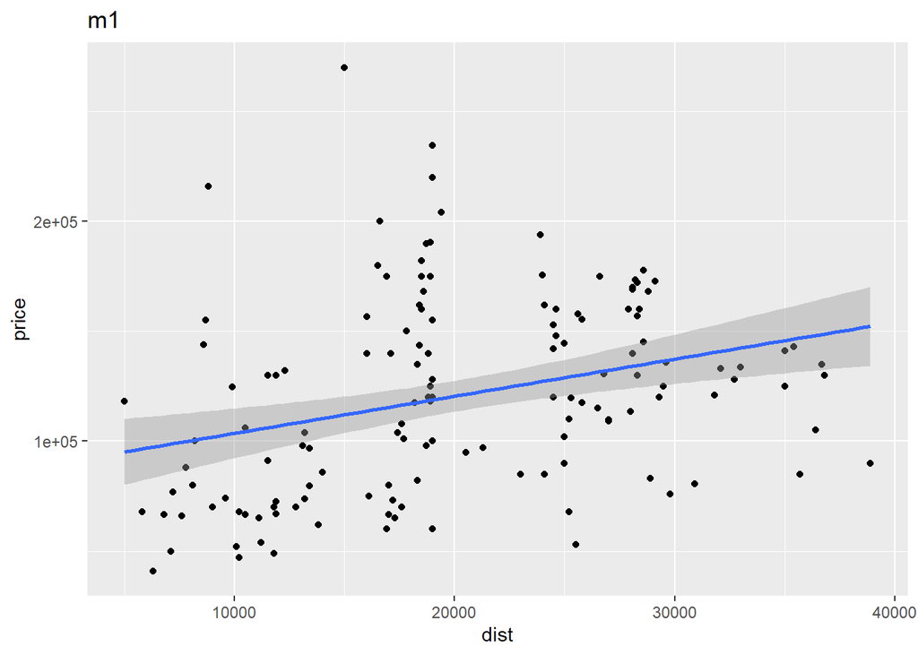

```r
#create scatter plots
ggplot(m1, aes(y = price, x = dist)) + geom_point() + stat_smooth(method = "lm")+ ggtitle("m1")
```

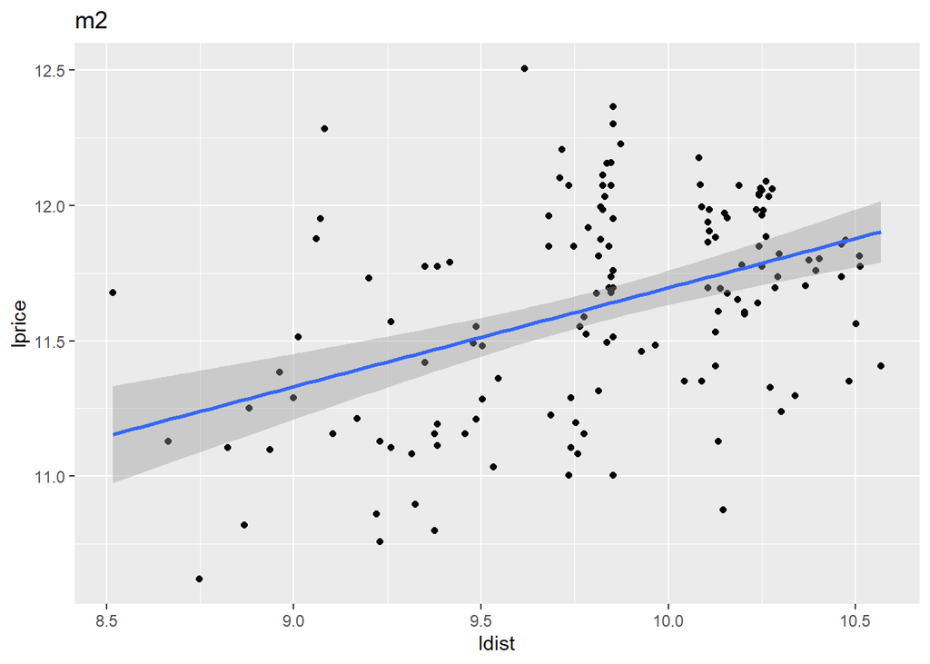

```r
ggplot(m2, aes(y = lprice, x = ldist)) + geom_point() + stat_smooth(method = "lm")+ ggtitle("m2")
```

In m1, the coefficient of dist is 1.685, meaning that selling price is predicted to increase by $1.685 when distance from house to incinerator increases by 1 foot. In m2, the coefficient of ldist is 0.365, meaning that the selling price is predicted to increase by 0.365% when distance from house to incinerator increases by 1%. In both models, the effect on distance from house to incinerator is statistically significant at 1 % level.

I would use m2 (regressing log(price) on log(dist)). The reason is because firstly, m2 has a higher adjusted $R^2$ (0.174) than m1 (0.087), indicating that the sum of squared residuals is smaller in m2 than m1, and that m2 can explain the data better. Secondly, based on the residual histogram, the residuals of m1 skew to the right, which indicates violation of the normality assumptions (error term should follow normal distribution and has an expected value of 0). In contrast, the residuals of m2 appear to be closer to normal distribution. The above suggests that log transformation of variables allows the model to better conform to the OLS assumptions. Therefore, m2 is recommended to use for the study.

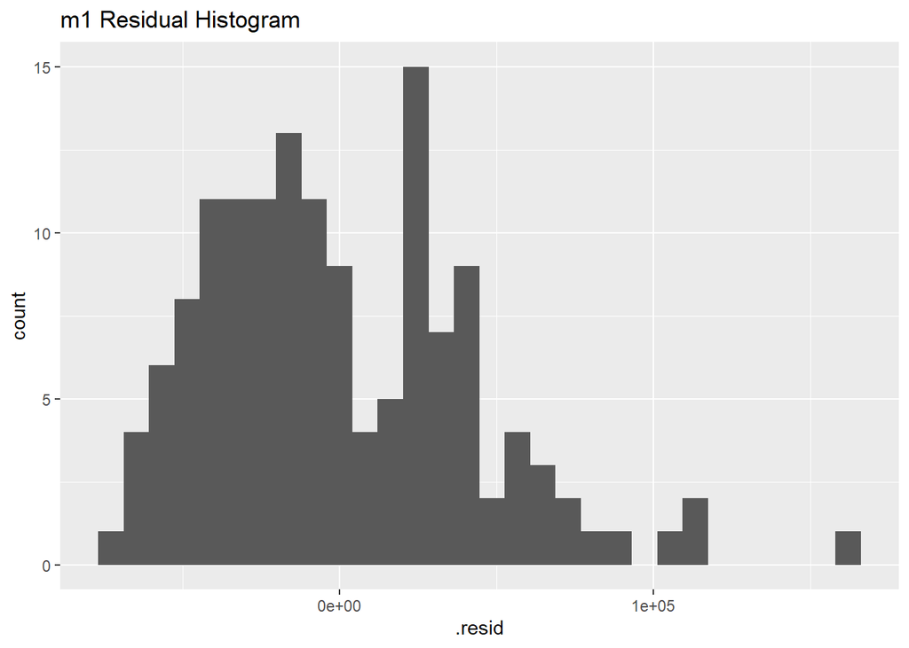

```r
ggplot(data = m1, aes(x = .resid)) + geom_histogram() + ggtitle("m1 Residual Histogram")
```

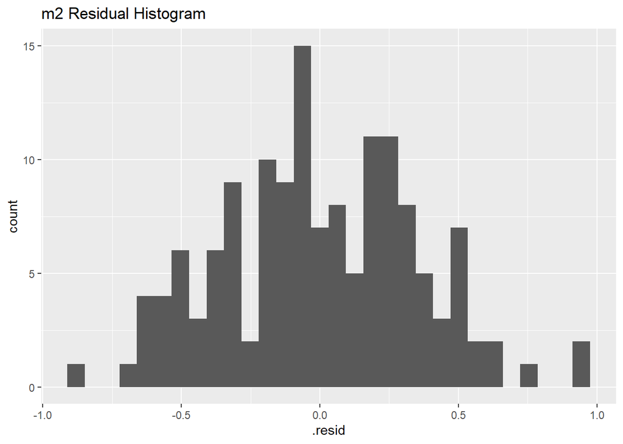

```r
ggplot(data = m2, aes(x = .resid)) + geom_histogram() + ggtitle("m2 Residual Histogram")
```

2. Suppose you choose to regress $price$ on $dist$. What is a 95% prediction interval for a house that is 20,000 feet away from the incinerator (Answer this question without using the predict() function)? Add the bounds of the 95% prediction interval to a scatter plot of $price$ versus $dist$. What percentage of your observations are outside this interval?

**answer 1.2**

```r
# z score of 95% prediction interval is approximately 1.96
# use z score instead of t score since we have data points > 30
z = round(qnorm(1-0.05/2),2)
z
```

[1] 1.96

```r
# create m3: regress price on (dist-20000)
m3 = lm(data = data1981, price~I(dist-20000))
stargazer(m3, type = 'html')
```

|  | *Dependent variable:* |
| --- | --- |
|  | price |
| I(dist - 20000) | 1.685*** |
|  | (0.444) |
| Constant | 120,460.800*** |
|  | (3,557.352) |
| Observations | 142 |
| R<sup>2</sup> | 0.093 |
| Adjusted R<sup>2</sup> | 0.087 |
| Residual Std. Error | 42,386.720 (df = 140) |
| F Statistic | 14.433*** (df = 1; 140) |
| *Note:* | p<0.1; p<0.05; p<0.01 |

The 95% prediction interval can be constructed based on the formula:
$$\hat{y_f}± z_{\alpha/2} * [\hat{\sigma}^2 +
se(\hat{y_f)}^2 ]^{1/2}$$
. $\hat{y_f}$ is the intercept of m3, 120460.8, $se(\hat{y_f)}$ is 3557.352. $\hat{\sigma}$ is 42386.72

```r
# upper bound
u = 120460.8 + 1.96*(42386.72^2 + 3557.352^2)^0.5
u
```

```
## [1] 203830.8
```

```r
#lower bound
l = 120460.8 - 1.96*(42386.72^2 + 3557.352^2)^0.5
l
```

```
## [1] 37090.76
```

```r
# how many % of data is outside the interval
outside = nrow(data1981[(data1981$price > u) | (data1981$price < l), ])
total = nrow(data1981)
outside/total
```

```
## [1] 0.03521127
```

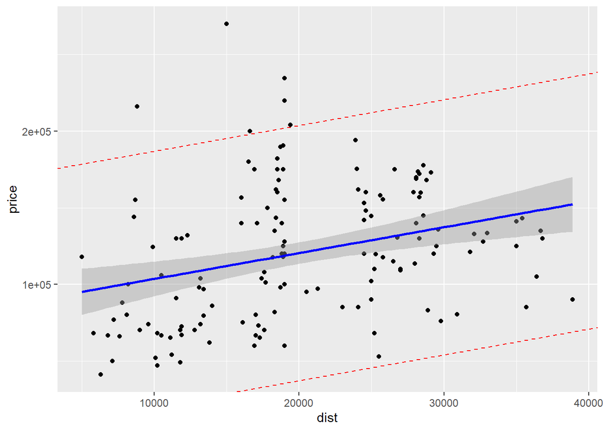

```r
# create a plot
interval = 1.96*(42386.72^2 + 3557.352^2)^0.5
intercept = m1$coefficients[1]
slope = m1$coefficients[2]

ggplot(m1, aes(y = price, x = dist)) + geom_point() + stat_smooth(method = "lm", col = "blue") + geom_abline(intercept = intercept + interval, slope = slope, linetype = 'dashed', col = 'red') + geom_abline(intercept = intercept - interval, slope = slope, linetype = 'dashed', col = 'red')
```

The 95% prediction interval is $[ 37090.76, 203830.8 ]$ for a house that is 20,000 feet away from the incinerator. 3.52% of data is outside the prediction interval.

3. Now suppose that you choose to regress $\log(price)$ on $\log(dist)$. Report the results. Would you choose to add the square of $\log(dist)$ to the model? Explain.

**answer 1.3**

```r
# recall m2: regress lprice on ldist
# create m4: regress lprice on ldist and ldist^2

m4 = lm(data = data1981, lprice~ldist+ I(ldist^2))
stargazer(m2,m4,type = 'html', align = TRUE)
```

|  | *Dependent variable:* |  |
| --- | --- | --- |
|  | lprice |  |
|  | (1) | (2) |
| ldist | 0.365*** | 3.979 |
|  | (0.066) | (2.416) |
| I(ldist2) |  | -0.187 |
|  |  | (0.125) |
| Constant | 8.047*** | -9.391 |
|  | (0.646) | (11.672) |
| Observations | 142 | 142 |
| R<sup>2</sup> | 0.180 | 0.193 |
| Adjusted R<sup>2</sup> | 0.174 | 0.182 |
| Residual Std. Error | 0.354 (df = 140) | 0.353 (df = 139) |
| F Statistic | 30.786*** (df = 1; 140) | 16.649*** (df = 2; 139) |
| *Note:* | p<0.1; p<0.05; p<0.01 |  |

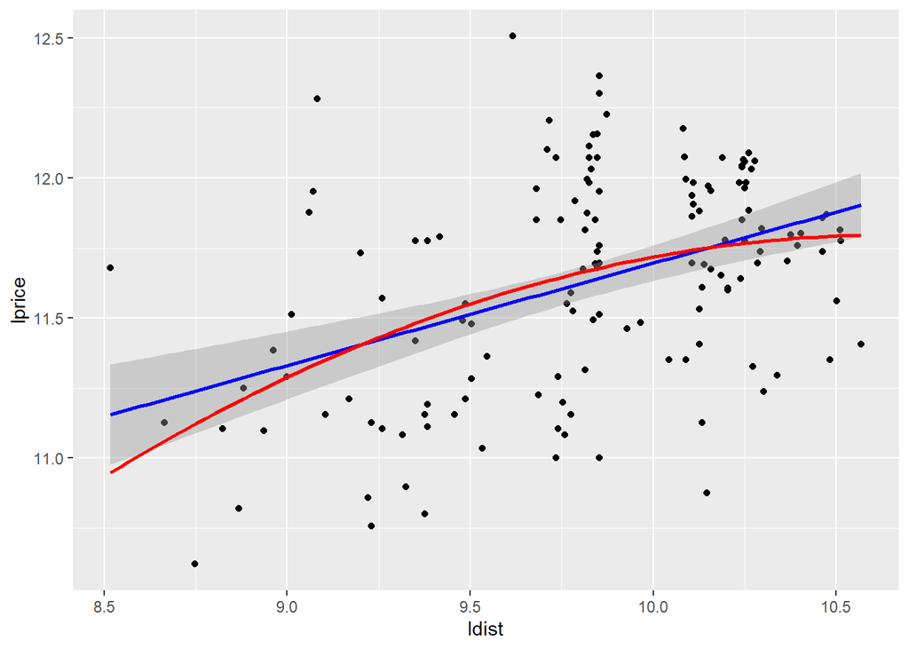

```r
ggplot(m2, aes(y = lprice, x = ldist)) + geom_point() + stat_smooth(method = "lm", col = "blue") +  stat_smooth(method = 'lm', formula = y ~ x + I(x^2), se = F, col = "red")
```

4. To the simple regression model in part 3 (without the square of $\log(dist)$), add the variables $\log(intst)$, $\log(area)$, $\log(land)$, $rooms$, $baths$, and $age$, where $intst$ is distance from house to interstate (i.e., a major system of highways running between US states) entrance ramp measured in feet, $area$ is square footage of the house, $land$ is the lot size in square feet, $rooms$ is total number of rooms, $baths$ is number of bathrooms, and $age$ is age of the house in years. Now, what do you conclude about the effects of the incinerator? Explain why parts 3 and 4 give conflicting results.

**answer 1.4**

```r
# create m5: regress ldist on lintst, larea, lland, rooms, baths, and age
m5 = lm(data = data1981, lprice~ldist+lintst+larea+lland+rooms+baths+age)
stargazer(m2, m5,type = 'html', align = TRUE)
```

|  | *Dependent variable:* |  |
| --- | --- | --- |
|  | lprice |  |
|  | (1) | (2) |
| ldist | 0.365*** | 0.055 |
|  | (0.066) | (0.058) |
| lintst |  | -0.039 |
|  |  | (0.052) |
| larea |  | 0.319*** |
|  |  | (0.076) |
| lland |  | 0.077* |
|  |  | (0.040) |
| rooms |  | 0.043 |
|  |  | (0.028) |
| baths |  | 0.167*** |
|  |  | (0.042) |
| age |  | -0.004*** |
|  |  | (0.001) |
| Constant | 8.047*** | 7.592*** |
|  | (0.646) | (0.642) |
| Observations | 142 | 142 |
| R<sup>2</sup> | 0.180 | 0.748 |
| Adjusted R<sup>2</sup> | 0.174 | 0.734 |
| Residual Std. Error | 0.354 (df = 140) | 0.201 (df = 134) |
| F Statistic | 30.786*** (df = 1; 140) | 56.683*** (df = 7; 134) |
| *Note:* | p<0.1; p<0.05; p<0.01 |  |

In m5, $ldist$,$lintst$, and $rooms$ are not statistically significant at 10% level. $larea$, $baths$, $age$ are significant at 1% level. $lland$ is significant at 10% but not 5% level. As we add more variables to the model, the coefficient will surely differ from the one in a SLR model, since it is inevitable in reality that the independent variable correlates to each other and the dependent variable to some degree.

The effect of locating close to incinerators on housing price becomes smaller, from 0.365 in m2 to 0.055 in m5.The reason could be in m2, there is only one independent variable $ldist$ and many other factors are omitted. The coefficient of $ldist$ in m2 contains omitted variable bias, so the effect is contains information of other factors such as $larea$, $baths$, etc, that are also significant to $lprice$. While in m5, these factors are separated out and omitted variable bias is mitigated.

## Question 2 (40 marks)

Use the data in gpa2.RData for this exercise. Consider the equation
$$colgpa = \beta_0 + \beta_1 hsperc + \beta_2
sat + \beta_3 female + \beta_4 athlete +u,$$
where $colgpa$ is cumulative college grade point average; $hsperc$ is academic percentile in high school (from top); $sat$ is combined SAT score (a standardized test widely used for college admission in US); $female$ is a binary gender variable; and $athlete$ is a binary variable, which is one for student athletes.

1. Estimate the equation and report the results. What is the estimated GPA differential between athletes and nonathletes? Is it statistically significant?

**answer 2.1**

```r
load("gpa2.RData")
desc
```

| variable | label |
| --- | --- |
| sat | combined SAT score |
| tothrs | total hours through fall semest |
| colgpa | GPA after fall semester |
| athlete | =1 if athlete |
| verbmath | verbal/math SAT score |
| hsize | size grad. class, 100s |
| hsrank | rank in grad. class |
| hsperc | high school percentile, from top |
| female | =1 if female |
| white | =1 if white |

[output cut: 2 more lines]

```r
# no missing values
sum(is.na(data$colgpa))
```

[1] 0

```r
sum(is.na(data$hsperc))
```

[1] 0

```r
sum(is.na(data$sat))
```

[1] 0

```r
sum(is.na(data$female))
```

[1] 0

```r
sum(is.na(data$athlete))
```

[1] 0

```r
m6 = lm(data = data, colgpa~hsperc+sat+female+athlete)
stargazer(m6, type = 'html')
```

|  | *Dependent variable:* |
| --- | --- |
|  | colgpa |
| hsperc | -0.013*** |
|  | (0.001) |
| sat | 0.002*** |
|  | (0.0001) |
| female | 0.156*** |
|  | (0.018) |
| athlete | 0.156*** |
|  | (0.042) |
| Constant | 1.147*** |
|  | (0.076) |
| Observations | 4,137 |
| R<sup>2</sup> | 0.288 |
| Adjusted R<sup>2</sup> | 0.287 |
| Residual Std. Error | 0.556 (df = 4132) |
| F Statistic | 417.105*** (df = 4; 4132) |
| *Note:* | p<0.1; p<0.05; p<0.01 |

The effect of $hsperc$, $sat$, $female$, and $athlete$ are all statistically significant at 1% level. The coefficient of $athlete$ is 0.156, meaning that if the subject is an athlete, his/her college GPA is predicted to be higher than a non-athlete by 0.156, given all other factors the same. The estimated GPA differential between athletes and nonathletes is $\hat{\beta_4} = 0.156$ while holding all other factors the same.

2. Drop $sat$ from the model and reestimate the equation. Now, what is the estimated effect of being an athlete? Discuss why the estimate is different than that obtained in part 1.

**answer 2.2**

```r
m7 = lm(data = data, colgpa~hsperc+female+athlete)
stargazer(m7, type = 'html')
```

|  | *Dependent variable:* |
| --- | --- |
|  | colgpa |
| hsperc | -0.017*** |
|  | (0.001) |
| female | 0.060*** |
|  | (0.019) |
| athlete | -0.002 |
|  | (0.045) |
| Constant | 2.948*** |
|  | (0.017) |
| Observations | 4,137 |
| R<sup>2</sup> | 0.186 |
| Adjusted R<sup>2</sup> | 0.185 |
| Residual Std. Error | 0.595 (df = 4133) |
| F Statistic | 314.077*** (df = 3; 4133) |
| *Note:* | p<0.1; p<0.05; p<0.01 |

The estimated effect of being an athlete on college GPA is -0.002 based on the model, meaning that the college GPA of a athlete is predicted to be lower than a nonathelete by 0.002, given all other factors the same. However, athlete now becomes not statistically significant even at 10% level. The results of m7 (coefficient = -0.002) and m6(coefficient = 0.156) are different because $sat$ and $athlete$ are negatively correlated and the effect of $sat$ on $colgpa$ is significant. Therefore, if we omit $sat$ in the model, omitted variable bias occurs and the coefficient of $athlete$ is no longer accurate. In m7, the coefficient of $athlete$ includes the omitted variable bias and information about $sat$.

```r
cor(data$athlete, data$sat)
```

```
## [1] -0.1850938
```

3. In the model, allow the effect of being an athlete to differ by gender and test the null hypothesis that there is no difference between women athletes and women nonathletes.

**answer 2.3**

```r
# the interaction term female*athlete allows the effect of being an athlete on college GPA to differ between genders
# create m8: regress colgpa on hsperc, sat, female, athlete, female*athlete
m8 = lm(data = data,colgpa~hsperc+sat+female*athlete)
stargazer(m8, type='html')
```

|  | *Dependent variable:* |
| --- | --- |
|  | colgpa |
| hsperc | -0.013*** |
|  | (0.001) |
| sat | 0.002*** |
|  | (0.0001) |
| female | 0.154*** |
|  | (0.018) |
| athlete | 0.148*** |
|  | (0.048) |
| female:athlete | 0.032 |
|  | (0.096) |
| Constant | 1.148*** |
|  | (0.076) |
| Observations | 4,137 |
| R<sup>2</sup> | 0.288 |
| Adjusted R<sup>2</sup> | 0.287 |
| Residual Std. Error | 0.556 (df = 4131) |
| F Statistic | 333.635*** (df = 5; 4131) |
| *Note:* | p<0.1; p<0.05; p<0.01 |

```r
# hypothesis test
# H0: athlete and female*athlete have no effect on colgpa, beta_4 =0 and beta_5 = 0
# H1: H0 is not true
linearHypothesis(m8, c('athlete=0', 'female:athlete=0'))
```

|  | Res.Df | RSS | Df | Sum of Sq | F | Pr(>F) |
| --- | --- | --- | --- | --- | --- | --- |
| 1 | 4133 | 1282.322 | NA | NA | NA | NA |
| 2 | 4131 | 1278.082 | 2 | 4.239307 | 6.851115 | 0.001070342 |

$$\hat{colgpa} = \hat{\beta_0} +
\hat{\beta_1} hsperc + \hat{\beta_2} sat + \hat{\beta_3} female +
\hat{\beta_4} athlete + \hat{\beta_5} female*athlete$$
When the subject is a female athlete, her predicted college GPA is: $\hat{\beta_0} + \hat{\beta_1} hsperc + \hat{\beta_2} sat + \hat{\beta_3} + \hat{\beta_4} + \hat{\beta_5}$ When the subject is a female non-athlete, her predicted college GPA is : $\hat{\beta_0} + \hat{\beta_1} hsperc + \hat{\beta_2} sat + \hat{\beta_3}$ The estimated difference between the two groups, given all other factors the same, is $\hat{\beta_4} + \hat{\beta_5} = 0.148 + 0.032 = 0.18$ .This means that the college GPA of female athletes is predicted to be higher than the one of female non-athletes by 0.18, given all other factors the same.

According to F test, F test statistic has a p-value of 0.001070342 < 0.05, so we are able to reject the null hypothesis that there are no difference between female athlete and female non-athletes. The above also suggests that the effects of $athlete$ and $female*athlete$ on college GPA are jointly significant at 5% level.

4. Does the effect of $sat$ on $colgpa$ differ by gender? Justify your answer.

**answer 2.4**

```r
m9 = lm(data = data,colgpa ~ hsperc + female*sat + female*athlete)
stargazer(m9, type='html')
```

|  | *Dependent variable:* |
| --- | --- |
|  | colgpa |
| hsperc | -0.013*** |
|  | (0.001) |
| female | 0.091 |
|  | (0.136) |
| sat | 0.002*** |
|  | (0.0001) |
| athlete | 0.145*** |
|  | (0.049) |
| female:sat | 0.0001 |
|  | (0.0001) |
| female:athlete | 0.039 |
|  | (0.097) |
| Constant | 1.175*** |
|  | (0.095) |
| Observations | 4,137 |
| R<sup>2</sup> | 0.288 |
| Adjusted R<sup>2</sup> | 0.287 |
| Residual Std. Error | 0.556 (df = 4130) |
| F Statistic | 278.014*** (df = 6; 4130) |
| *Note:* | p<0.1; p<0.05; p<0.01 |

```r
# hypothesis test
# H0: female*sat have no effect on colgpa, beta_4 =0
# H1: H0 is not true
linearHypothesis(m9, 'female:sat=0') #with only one restriction, using t test yields the same p-value results
```

|  | Res.Df | RSS | Df | Sum of Sq | F | Pr(>F) |
| --- | --- | --- | --- | --- | --- | --- |
| 1 | 4131 | 1278.082 | NA | NA | NA | NA |
| 2 | 4130 | 1278.014 | 1 | 0.06853663 | 0.2214814 | 0.6379383 |

$$\hat{colgpa} = \hat{\beta_0} +
\hat{\beta_1} hsperc + \hat{\beta_2} female + \hat{\beta_3}sat +
\hat{\beta_4}female*sat + \hat{\beta_5}female*athlete$$
No. To know whether the effect of SAT on college GPA differ by gender, we added an interaction term $female*sat$ in the regression model. The interaction term allows the effect of SAT on college GPA to differ by gender. For instance, given all other factors including SAT the same, the college GPA of a female student is predicted to be $\hat{\beta_0} + \hat{\beta_1} hsperc + \hat{\beta_2} + \hat{\beta_3}sat + \hat{\beta_4}female*sat + \hat{\beta_5}female*athlete$, and the college GPA of a male student is predicted to be $\hat{\beta_0} + \hat{\beta_1} hsperc + \hat{\beta_3}sat$ . The difference is $\hat{\beta_2} +\hat{\beta_4}feamle*sat +\hat{\beta_5}female*athlete$ , and among the three terms, $\hat{\beta_4}female*sat$ represents the how much the effect of SAT on GPA differs when the subject is a female,

The F test statistic has a high p-value of 0.6379383. Therefore, we cannot reject the null hypothesis that there is no difference in the effect of SAT on GPA for the two genders.That is, for male and female students who have the same SAT score, that SAT score should translate to the same effect on college GPA.

## Question 3 (20 marks)

In class, we discussed using VIF to identify the issue of multicollinearity. Consider the following model:
$$y = \beta_0 + \beta_1 x_1 + \beta_2 x_2 +
u.$$
Now suppose that $VIF_1$ (variance inflation factor for $x_1$) is equal to 10. What is the correlation between $x_1$ and $x_2$ in the sample?

Based on the formula $VIF_1 = 1 / (1-R_1^2)$, we are able to infer $R_1^2 = 0.9$ from a VIF = 10. ($R^2 = 1 - 1/10 = 0.9$) $R_1^2$ is the $R^2$ derived from regressing x1 on x2 (other independent variable). Correlation coefficient $r$ between x1 and x2 is the square root of $R^2$ . $r = \sqrt {R^2} =\sqrt {0.9} \approx 0.949$. However, we cannot observe the direction of correlation based on the information, the $r$ derived from taking square root of a non-negative value $R^2$ is always non-negative. We can only tell the magnitude of the correlation and say that the the correlation could be +/- 0.949 in the sample.